# Projet d’analyse de données – Études sur les volcans méditerranéens

Jacobs Sofia & Bauer Julie Master STPE/MV – UCA Année académique 2025-2026

25 septembre 2025

# 1 Introduction

Dans le monde, on compte plus de **800 millions** de personnes vivant à proximité d’un volcan dont **200 millions à moins de 30 km d’un volcan actif** (CNRS, 2025). La caractérisation de l’aléa volcanique est donc essentielle pour **la sureté des habitants** en territoires volcaniques. Cela passe notamment par la compréhension de lien divers entre un volcan et **le type de dépôts ou l’intensité éruptive** qu’il produit. Notre étude se concentre sur la région méditerranéenne, en particulier sur **deux édifices grecs** et **quatre édifices italiens**, ces deux pays étant particulièrement connues pour leurs volcanismes très actifs et notamment plusieurs éruptions historiques. Les volcans italiens sont **l’Etna (Sicile, Italie), le Vésuve (Naples, sud de l’Italie), Lipari et Vulcano (Iles Eoliennes, Sicile, Italie). Les volcans grecques sont le Santorin et le Nisyros (Iles Dodecanese, Grèce)**. Ici nous ne nous concentrerons que sur **la période 2015 à 2025**.

Nous avons **les données de magnitudes, types de magma, profondeur du magma, le VEI, la classification et le volume estimé de produits** pour chaque édifice volcanique en plus des coordonnées des éruptions pour chaque édifices. L’objectif est de comprendre si il existe un **lien entre intensité de l’éruption (magnitude) et l’édifice volcanique** afin de déterminer quelle population s’expose à un **risque** plus important. Il sera aussi particulièrement intéressant de regarder le **lien possible entre volcans et type de magma** car le risques lié à un volcan est en partie du au type de matériaux qu’il produit. Ces résultats pourrait également nous permettre de déterminer si **les populations** d’un volcan en particulier s’exposent à un **risque accrue**. Enfin, d’un point de vus purement recherche nous allons nous intéressé au **lien entre édifice et profondeur du magma** car c’est grâce à la détection du magma en profondeur que l’on peut **anticiper une éruption**. Egalement à **la profondeur en fonction du type de magma** mais cela nous permettra, au terme d’une étude pétrologique ultérieure de prédire des **temps de remonté du magma et des durées pré-éruptifs** afin **d’alerter la population** en cas d’éruption imminente si ce lien existe.

# 2 Analyse exploiratoire des données

## 2.1 Chargement et préparation des données

```
## 'data.frame':    47 obs. of  14 variables:
##  $ Volcanoes       : chr  "Santorin" "Santorin" "Santorin" "Santorin" ...
##  $ Event.ID        : int  11946380 11933823 11933599 11933364 11405253 10724958 10878280 10813622 10813590 10757351 ...
##  $ Date            : chr  "12-02-25" "09-02-25" "09-02-25" "08-02-25" ...
##  $ Time            : chr  "08:37:47" "18:53:57" "01:35:15" "09:24:02" ...
##  $ Latitude        : num  36.4 36.4 36.5 36.4 36.4 ...
##  $ Longitude       : num  25.5 25.5 25.5 25.5 25.5 ...
##  $ Depth           : num  10 10 10 10 10 10 17.6 3.3 0 3.8 ...
##  $ Mag.Type        : chr  "MA" "MA" "MA" "MA" ...
##  $ Magnitude       : num  4.3 4.7 4.5 4.6 4.2 4.2 1.4 1.3 1.2 1.9 ...
##  $ Volume          : num  7.98e+07 2.00e+08 1.26e+08 1.59e+08 6.34e+07 ...
##  $ VEI.approximatif: int  3 3 3 3 3 3 1 1 1 1 ...
##  $ Region          : chr  "DODECANESE ISLANDS" "DODECANESE ISLANDS" "DODECANESE ISLANDS" "DODECANESE ISLANDS" ...
##  $ Country         : chr  "GREECE" "GREECE" "GREECE" "GREECE" ...
##  $ Classification  : chr  "Vulcanien" "Vulcanien" "Vulcanien" "Vulcanien" ...
```

```
##     Volcanoes      Event.ID      Date               Time
##  Etna    : 7   10796353: 2   Length:47          Length:47
##  Lipari  : 9   11629587: 2   Class :character   Class :character
##  Nisyros :11   5112637 : 1   Mode  :character   Mode  :character
##  Santorin:13   5149922 : 1
##  Vesuvio : 1   10570434: 1
##  Vulcano : 6   10570525: 1
##                (Other) :39
##     Latitude       Longitude         Depth         Mag.Type    Magnitude
##  Min.   :36.32   Min.   :14.49   Min.   :  0.00   MA   :14   Min.   :1.20
##  1st Qu.:36.45   1st Qu.:14.96   1st Qu.:  7.20   MB   :19   1st Qu.:1.80
##  Median :36.67   Median :25.39   Median : 10.00   MB-MA: 3   Median :2.30
##  Mean   :37.40   Mean   :20.70   Mean   : 27.57   MBa  : 1   Mean   :2.76
##  3rd Qu.:38.39   3rd Qu.:25.51   3rd Qu.: 14.91   ML   : 9   3rd Qu.:4.20
##  Max.   :40.79   Max.   :27.25   Max.   :225.42   MR   : 1   Max.   :5.30
##
##      Volume          VEI.approximatif                Region     Country
##  Min.   :    63396   1:24             DODECANESE ISLANDS:24    ITALY:23
##  1st Qu.:   252383   2: 9             SICILY            :22   GREECE:24
##  Median :   798105   3:13             SOUTHERN          : 1
##  Mean   : 50123635   4: 1
##  3rd Qu.: 63395728
##  Max.   :798104926
##
##                Classification
##  Hawaien/Strombolien  :24
##  Strombolien/Vulcanien: 9
##  Vulcanien            :13
##  Vulcanien/Plinien    : 1
##
##
##
```

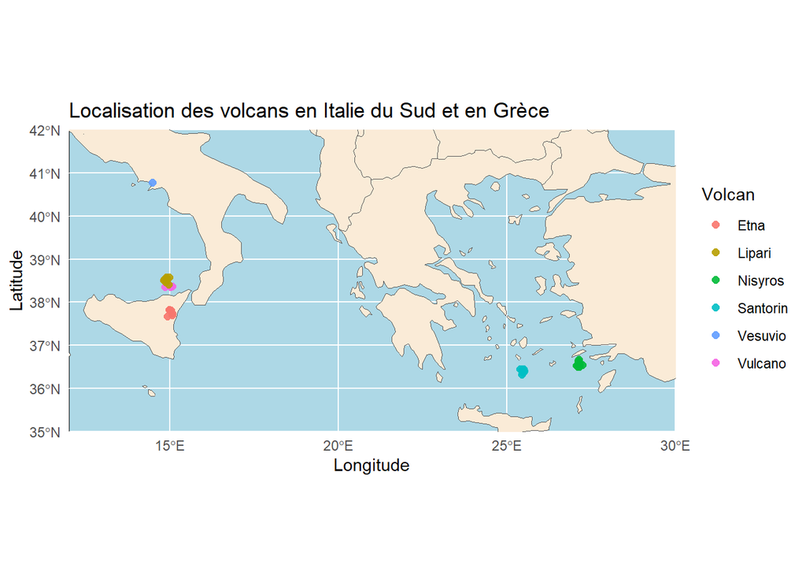

```
## 'data.frame':    22 obs. of  14 variables:
##  $ Volcanoes       : Factor w/ 6 levels "Etna","Lipari",..: 1 1 1 1 1 1 5 6 6 6 ...
##  $ Event.ID        : Factor w/ 45 levels "5112637","5149922",..: 31 30 29 28 35 36 17 41 24 21 ...
##  $ Date            : chr  "17-08-15" "12-08-15" "12-08-15" "12-08-15" ...
##  $ Time            : chr  "02:18:26" "11:41:46" "11:35:53" "03:56:14" ...
##  $ Latitude        : num  37.7 37.8 37.8 37.8 37.7 ...
##  $ Longitude       : num  15.1 15 15 15 15.1 ...
##  $ Depth           : num  7.2 29.9 28.6 30 10 ...
##  $ Mag.Type        : Factor w/ 6 levels "MA","MB","MB-MA",..: 2 2 2 2 1 1 2 1 2 2 ...
##  $ Magnitude       : num  1.5 1.4 1.5 1.5 4.3 1.8 2.2 4.4 1.3 1.2 ...
##  $ Volume          : num  126491 100475 126491 126491 79810493 ...
##  $ VEI.approximatif: Factor w/ 4 levels "1","2","3","4": 1 1 1 1 3 1 1 3 1 1 ...
##  $ Region          : Factor w/ 3 levels "DODECANESE ISLANDS",..: 2 2 2 2 2 2 3 2 2 2 ...
##  $ Country         : Factor w/ 2 levels " ITALY","GREECE": 1 1 1 1 1 1 1 1 1 1 ...
##  $ Classification  : Factor w/ 4 levels "Hawaien/Strombolien",..: 1 1 1 1 3 1 1 3 1 1 ...
```

```
## 'data.frame':    24 obs. of  14 variables:
##  $ Volcanoes       : Factor w/ 6 levels "Etna","Lipari",..: 4 4 4 4 4 4 4 4 4 4 ...
##  $ Event.ID        : Factor w/ 45 levels "5112637","5149922",..: 45 44 43 42 38 16 33 23 22 18 ...
##  $ Date            : chr  "12-02-25" "09-02-25" "09-02-25" "08-02-25" ...
##  $ Time            : chr  "08:37:47" "18:53:57" "01:35:15" "09:24:02" ...
##  $ Latitude        : num  36.4 36.4 36.5 36.4 36.4 ...
##  $ Longitude       : num  25.5 25.5 25.5 25.5 25.5 ...
##  $ Depth           : num  10 10 10 10 10 10 17.6 3.3 0 3.8 ...
##  $ Mag.Type        : Factor w/ 6 levels "MA","MB","MB-MA",..: 1 1 1 1 1 1 5 5 5 5 ...
##  $ Magnitude       : num  4.3 4.7 4.5 4.6 4.2 4.2 1.4 1.3 1.2 1.9 ...
##  $ Volume          : num  7.98e+07 2.00e+08 1.26e+08 1.59e+08 6.34e+07 ...
##  $ VEI.approximatif: Factor w/ 4 levels "1","2","3","4": 3 3 3 3 3 3 1 1 1 1 ...
##  $ Region          : Factor w/ 3 levels "DODECANESE ISLANDS",..: 1 1 1 1 1 1 1 1 1 1 ...
##  $ Country         : Factor w/ 2 levels " ITALY","GREECE": 2 2 2 2 2 2 2 2 2 2 ...
##  $ Classification  : Factor w/ 4 levels "Hawaien/Strombolien",..: 3 3 3 3 3 3 1 1 1 1 ...
```

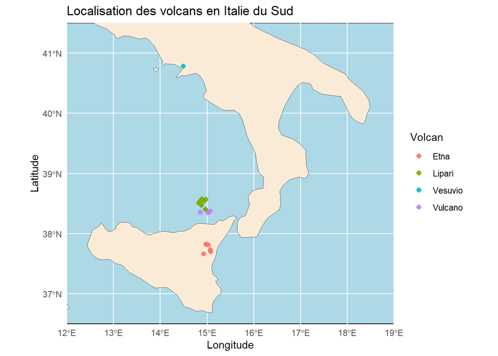

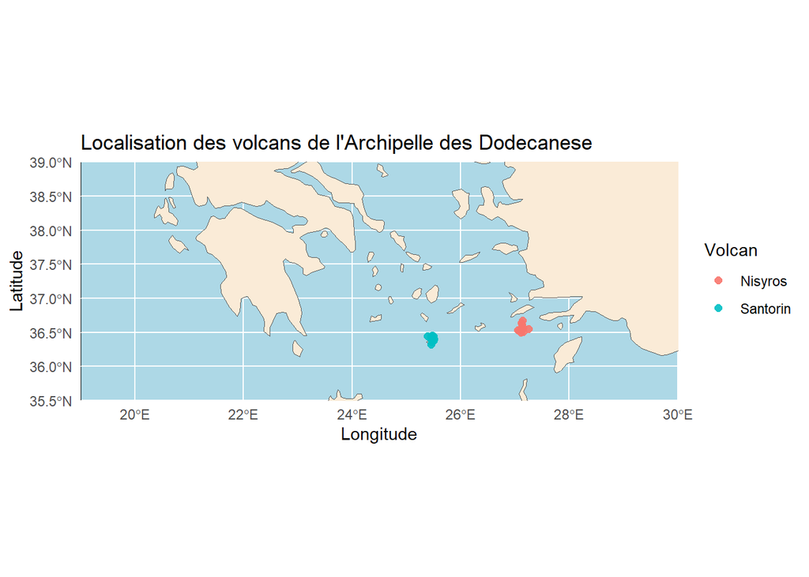

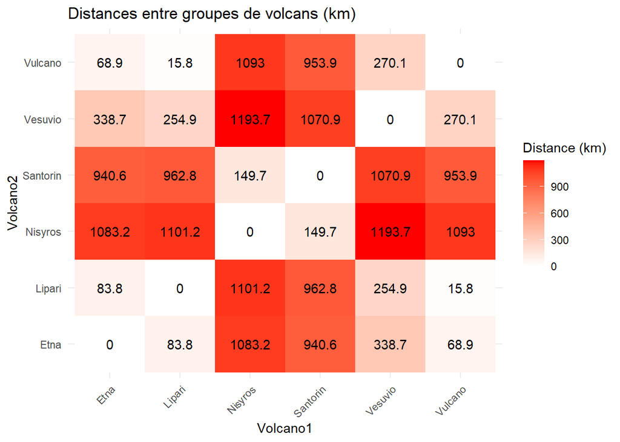

## 2.2 Calcule des paramètres de dispersions

```
##       Group  Variable                Variance            Mean
## 1    Global     Depth              2683.43422        27.56902
## 2    Global Magnitude                 1.56159         2.75957
## 3    Global    Volume 15973504288128854.00000  50123634.88617
## 4  Santorin     Depth                23.21269         7.44615
## 5  Santorin Magnitude                 2.25859         2.87692
## 6  Santorin    Volume  4908889462161985.00000  53385265.08462
## 7      Etna     Depth               130.90810        19.41429
## 8      Etna Magnitude                 1.07333         2.00000
## 9      Etna    Volume   905672258098802.00000  11563260.61857
## 10  Vesuvio     Depth                      NA         0.50000
## 11  Vesuvio Magnitude                      NA         2.20000
## 12  Vesuvio    Volume                      NA    633957.28000
## 13  Vulcano     Depth                10.43741         9.28700
## 14  Vulcano Magnitude                 1.36967         2.21667
## 15  Vulcano    Volume  1669085589528357.50000  17084959.71833
## 16   Lipari     Depth              8245.75305        54.22689
## 17   Lipari Magnitude                 0.84000         2.90000
## 18   Lipari    Volume  1902945411863623.50000  23549175.67556
## 19  Nisyros     Depth              3726.96190        47.16182
## 20  Nisyros Magnitude                 1.45855         3.33636
## 21  Nisyros    Volume 57457175635148752.00000 115070297.50455
```

Les valeurs de variance pour le volume et la magnitude sont ccohérentes par rapport au jeu de donné mais pour la profondeur, celles-ci sont beaucoup trop grande, cela s’explique par la présence d’outlier (7 point de donnée) de valeur beaucoup trop importante ou encore bien trop faibe qui donnent une dispersion des mesures exagérée.

On remarque qur pour le Vésuve nous n’avons qu’une seule éruption. Ainsi, nous ne pouvons pas calsuler de valeurs de dispersion et la profondeurs, la magnitude et le volume moyen seront les valeurs des données de l’éruption.

```
##        Depth    Magnitude       Volume
## 5.180187e+01 1.249636e+00 1.263863e+08
```

```
##     Depth Magnitude    Volume
## 1.8789885 0.4528366 2.5214917
```

```
## # A tibble: 6 × 6
##   Volcanoes mean_mag sd_mag min_mag max_mag median_mag
##   <fct>        <dbl>  <dbl>   <dbl>   <dbl>      <dbl>
## 1 Etna          2     1.04      1.4     4.3        1.5
## 2 Lipari        2.9   0.917     1.8     4.4        2.7
## 3 Nisyros       3.34  1.21      1.9     5.3        2.8
## 4 Santorin      2.88  1.50      1.2     4.7        1.9
## 5 Vesuvio       2.2  NA         2.2     2.2        2.2
## 6 Vulcano       2.22  1.17      1.2     4.4        2
```

Les volcans grecs porduisent une plus large d’éruption de magnitudes différentes que les volacans Italiens et se sont égalment eux qui produisent les éruptions les plus intenses avec Lipari. Cependant, il n’y pas de grande difference entre les différents paramètres de dispersion des les volcans.

# 3 Graphiques des analyses univariés

## 3.1 Analyse univariée de la profondeur

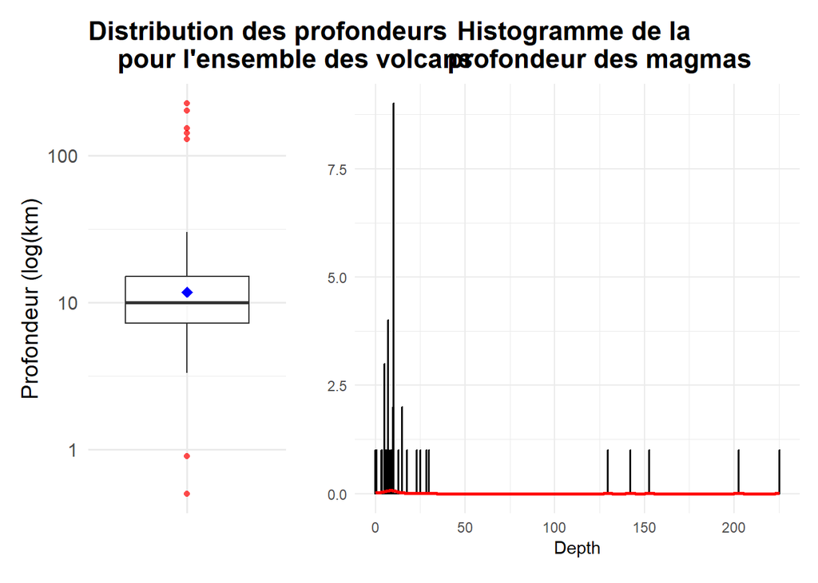

Pour l’ensemble des volcans, hormis les 7 outliers visibles en rouge sur le boxplot, la répartition des rpofondeurs sur l’hitogramme est symétique par rapport à une valeur centrale de 10 km. La majorité de nos magmas proviennet donc de chambre localsiée entre 15 et 7 km ce qui reste relativement superficielle.

## 3.2 Analyse univariée de la magnitude

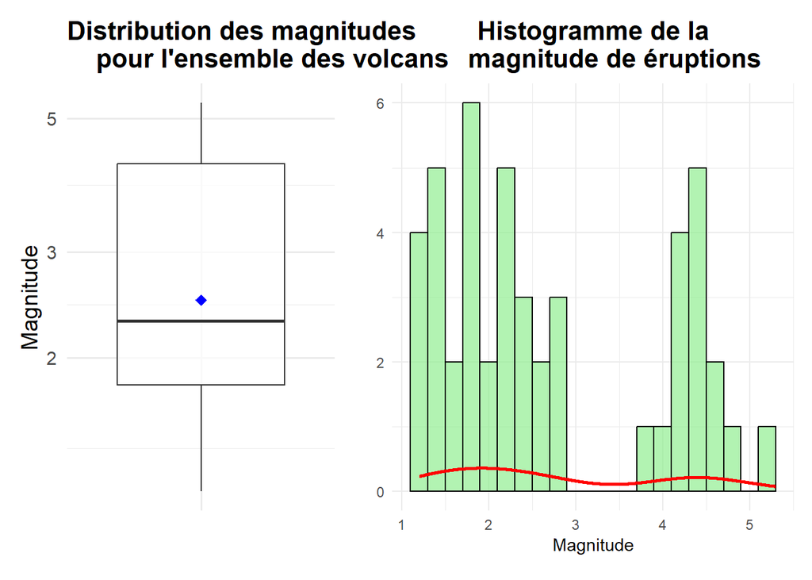

Le boxplot ne montre pas de valeur abérente. Cependant, l’histogramme des magnitudes montre une réputation bimodale des données. Une première partie des magnitudes se situe en dessous de 3, ce sont les valeurs de magnétudes faibles et une seconde partie se trouve au-dessus de 3 avec des valeurs dites fortes.

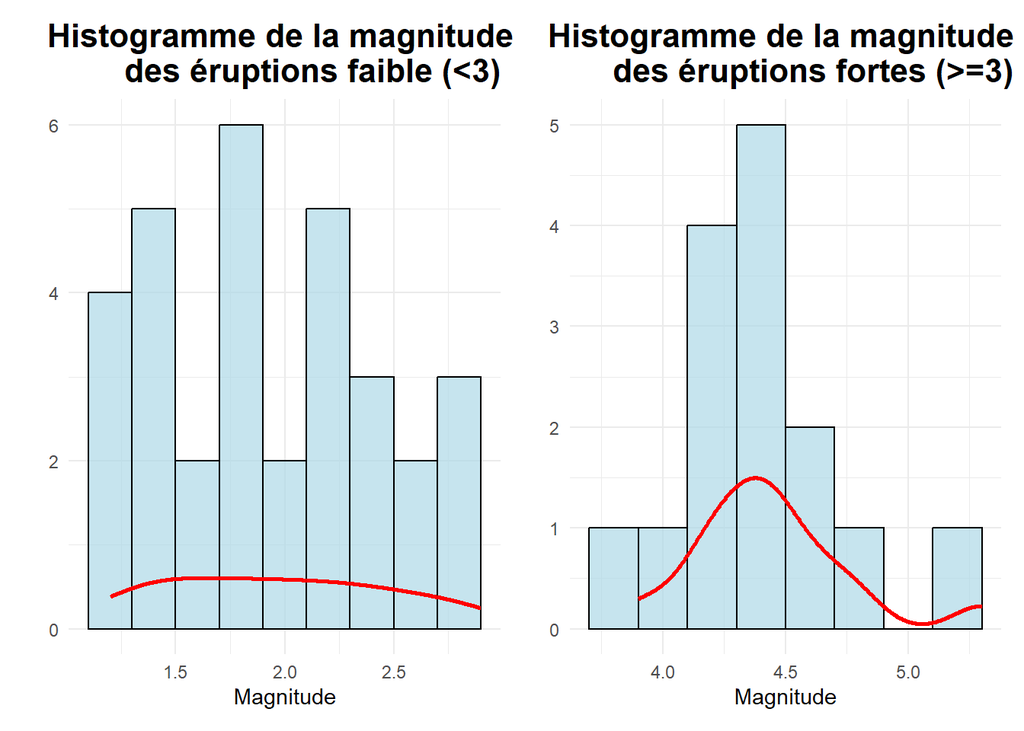

## 3.3 Analyse univariée du type de magma

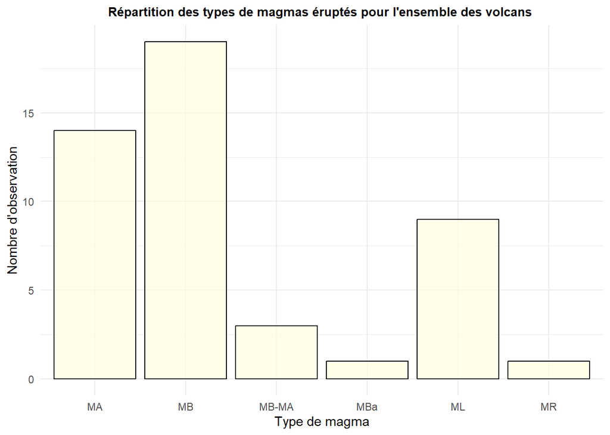

La majorité des magmas sont basaltique (MB) avec quelques occurences andésitique (MA) et latitique (ML=un magma latitique est un magma basaltique avec une texture particulière, il n’y a pas de différence de chimie importante). La série est basic et donc faiblement différencié. En effet il n’y a quaiment pas de magma différencié rhyolique (MR). La faible présence de basalte alcalin (MBa) révelle que les magmas générés appartiennen à la série subalcaline. Enfin, il se produit un petit peu de mélande car 3 magmas on uen composition intermédiaire entre basaltique et andésitique (MB-MA).

## 3.4 Analyse univariée du volume estimé

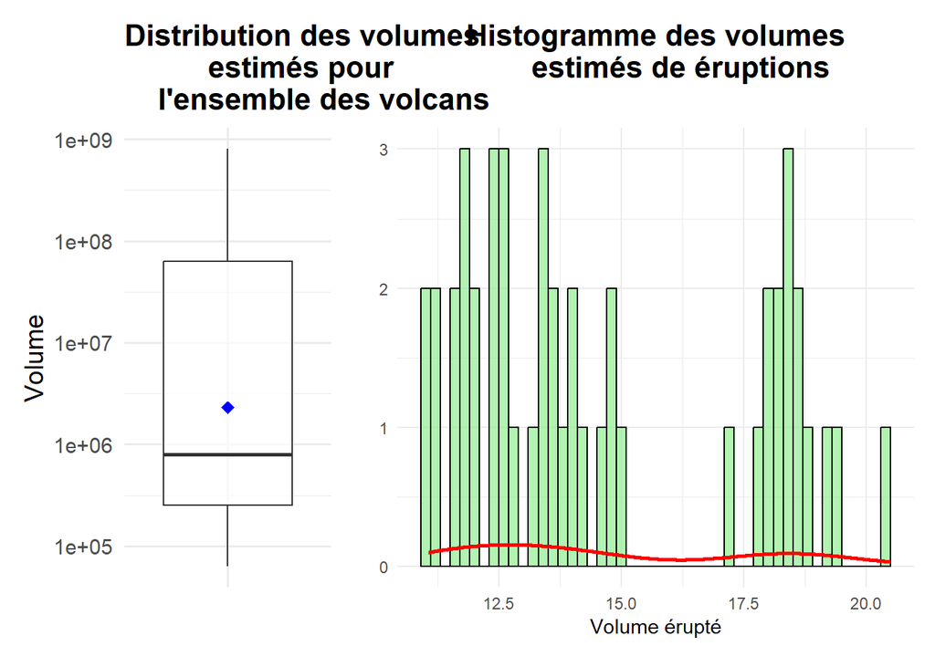

Pour les volumes estimés, on montrent également une répartition bimodale tres similaire à celle des magnitudes avec une valeur intermétidaiure entre les faibles et les forts volumes de 16,25 km3. Les forts volumes s’articulent autour d’un mode de 18,7 km3 et la faibles volume autoure de 12,5 km3 mais clea reste moins symétirque et forme plus un plateau. Les volumes estimés sont utilisés pour déterminer la magnitude de l’érution, il est donc logique qu’il suivent excatement la meme distibution pour l’hitogramme et le boxplot.

## 3.5 Analyse univariée du VEI estimé

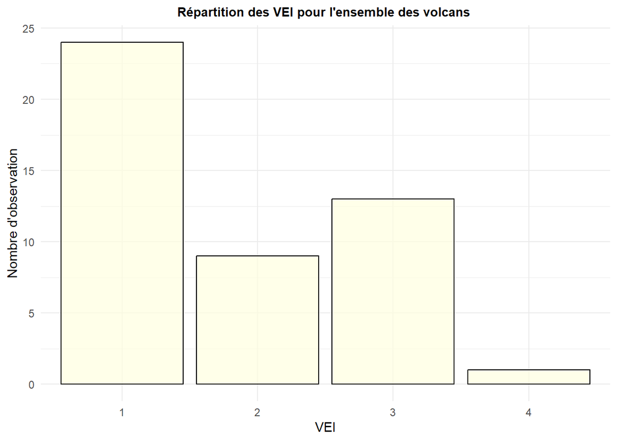

Le VEI est une échelle de 1 à 8 donnant l’intensité d’une éruption volcanique (1 tres peu intense et 8 extremement intense). Dans la région, la majorité des éruptions sont de faible intensité avec un VEI autour de 1 et 2 (plus de 30 cas), VEI 1 étant majoritaire. On enregistre des éruption peu à moyennement intense (3 à 4), mais elles restent minoritaire. Il n’y a aucune éruption avec un VEI supérieure à 4, ce qui est rassurant puisque les grosses éruptions ont une occurences de plusieurs centaines d’année et sont donc difficilement visible sur une période de 10 ans.

# 4 Analyse bivariés

Cette analyse univarié a permis de déterminer l’allure de chacune des variables du jeu données. Il est a présent possible d’étudier des liens possibles entre ces différentes données. Tout d’abord,

Lien entre la magnitude et la profondeur

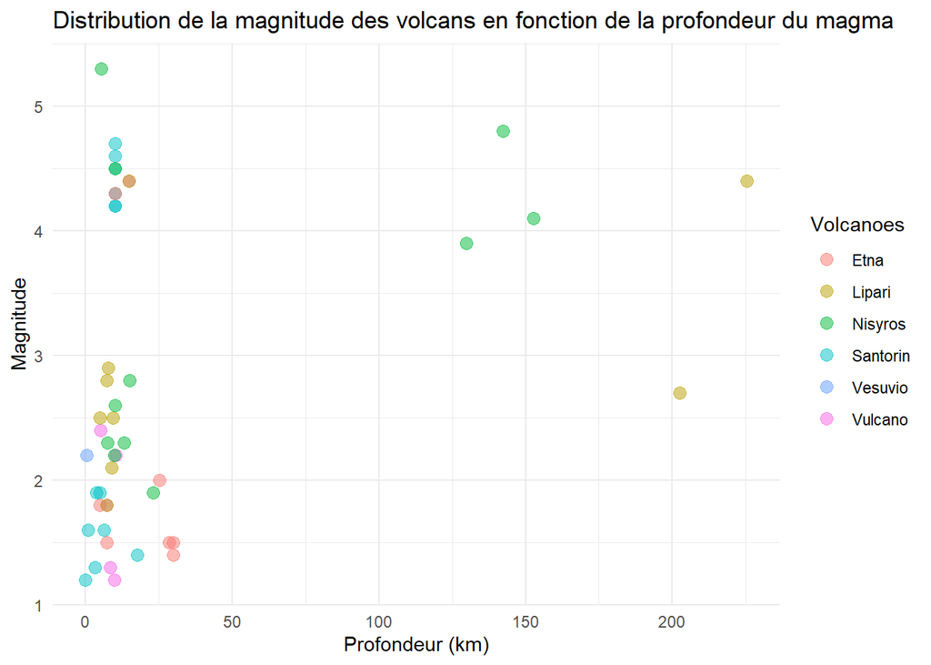

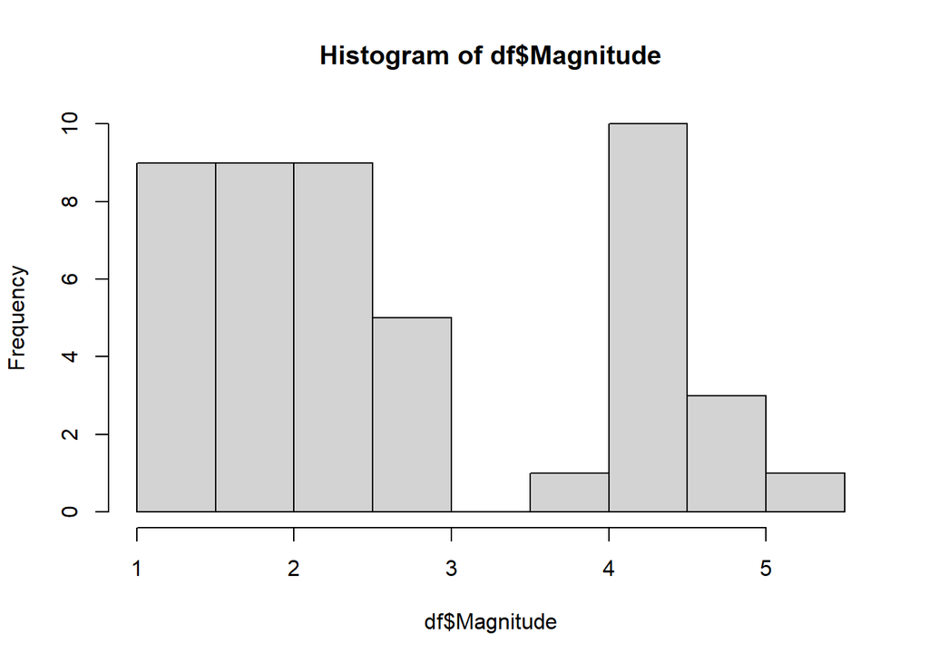

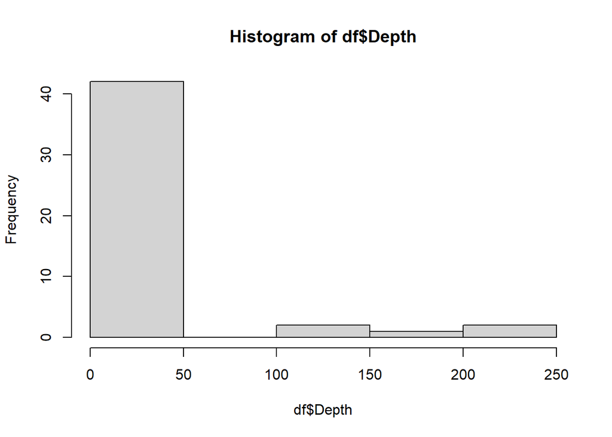

pas relation linéaire entre les données donc pas possible de faire une étude anova par rapport à ça

les données ne suivent pas une loi normal donc pas possible de faire une anova

```
##             Df Sum Sq Mean Sq F value Pr(>F)
## Magnitude    1  11522   11522   4.633 0.0368 *
## Residuals   45 111916    2487
## ---
## Signif. codes:  0 '***' 0.001 '**' 0.01 '*' 0.05 '.' 0.1 ' ' 1
```

normalement peut pas utiliser l’anova donc il faut utiliser un autre test comme kruskal-wallis

```
##
##  Kruskal-Wallis rank sum test
##
## data:  Depth by Volcanoes
## Kruskal-Wallis chi-squared = 9.6108, df = 5, p-value = 0.08705
```

```
##
##  Kruskal-Wallis rank sum test
##
## data:  Depth by Magnitude
## Kruskal-Wallis chi-squared = 31.564, df = 26, p-value = 0.2079
```

lien entre magnitude et le volume estimé

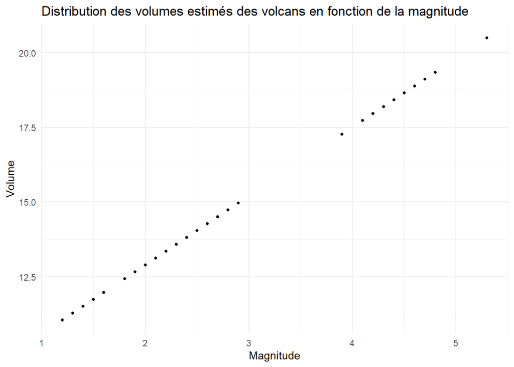

```
##
## Call:
## lm(formula = log(Volume) ~ Magnitude, data = df)
##
## Residuals:
##        Min         1Q     Median         3Q        Max
## -4.066e-08 -2.747e-09  8.390e-10  2.393e-09  2.790e-08
##
## Coefficients:
##              Estimate Std. Error   t value Pr(>|t|)
## (Intercept) 8.294e+00  4.917e-09 1.687e+09   <2e-16 ***
## Magnitude   2.303e+00  1.626e-09 1.416e+09   <2e-16 ***
## ---
## Signif. codes:  0 '***' 0.001 '**' 0.01 '*' 0.05 '.' 0.1 ' ' 1
##
## Residual standard error: 1.378e-08 on 45 degrees of freedom
## Multiple R-squared:      1,  Adjusted R-squared:      1
## F-statistic: 2.005e+18 on 1 and 45 DF,  p-value: < 2.2e-16
```

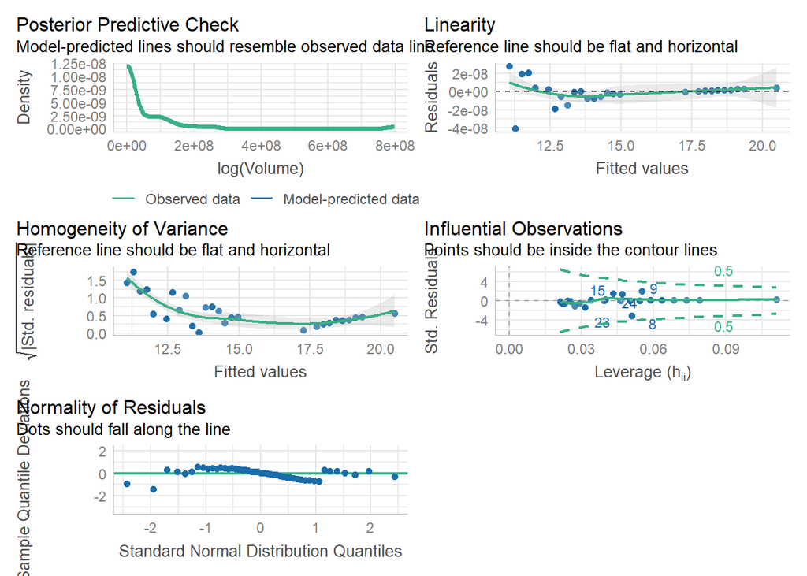

pas possible de faire une interprétation car R2 = 1 car directement calculé par rapport à la magnitude. C’est pour cela que la relation VEI et magnitude n’est pas pertinente car celle-ci est également tiré de la magnitude

Lien entre le volume et la profondeur

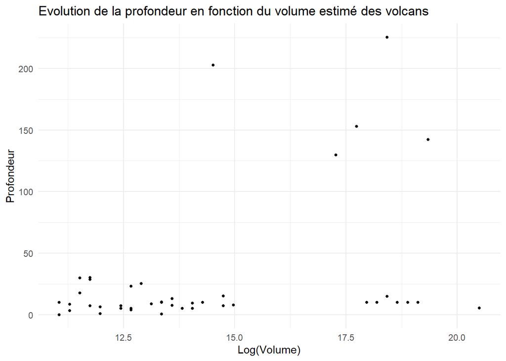

PAS DE TEST

pour moi elles ne sont pas distibué normalement après cela se discute. Si on considère que cela est normal déjà on peut faire deux groupes et faire une anova à plusieurs variables

```
##
##  F test to compare two variances
##
## data:  df_faible$Magnitude and df_forte$Magnitude
## F = 2.3771, num df = 31, denom df = 14, p-value = 0.0882
## alternative hypothesis: true ratio of variances is not equal to 1
## 95 percent confidence interval:
##  0.8723205 5.5180696
## sample estimates:
## ratio of variances
##            2.37705
```

```
##
##  Two Sample t-test
##
## data:  df_faible$Magnitude and df_forte$Magnitude
## t = -17.059, df = 45, p-value < 2.2e-16
## alternative hypothesis: true difference in means is not equal to 0
## 95 percent confidence interval:
##  -2.759537 -2.176713
## sample estimates:
## mean of x mean of y
##  1.971875  4.440000
```

```
## Levene's Test for Homogeneity of Variance (center = median)
##       Df F value Pr(>F)
## group  5  1.2315  0.312
##       41
```

```
##             Df Sum Sq Mean Sq F value Pr(>F)
## Volcanoes    5  10.14   2.027   1.347  0.264
## Residuals   41  61.70   1.505
```

Magnitude en fonction des volcans puis Magnitude en fonction du type de magma.

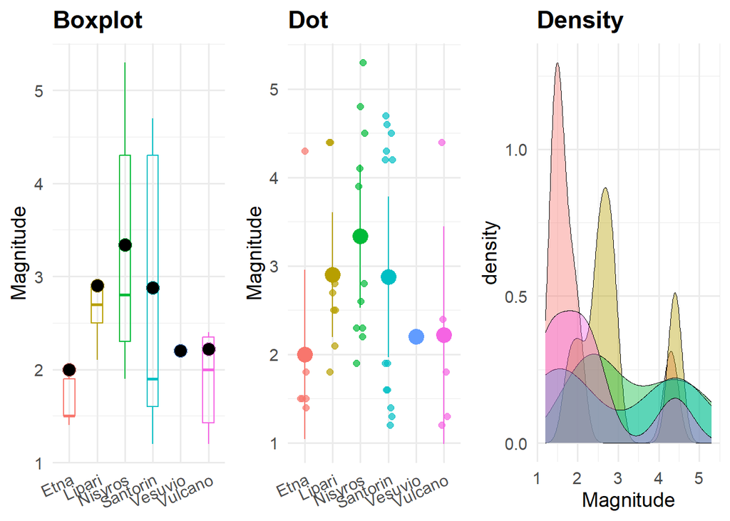

Possible d’observer que certains groupes ont des distributions bimodal et non pas juste normal

```
##             Df Sum Sq Mean Sq F value Pr(>F)
## Volcanoes    5  10.14   2.027   1.347  0.264
## Residuals   41  61.70   1.505
```

pas de différence significative entre les magnitudes moyennes des différents volcans

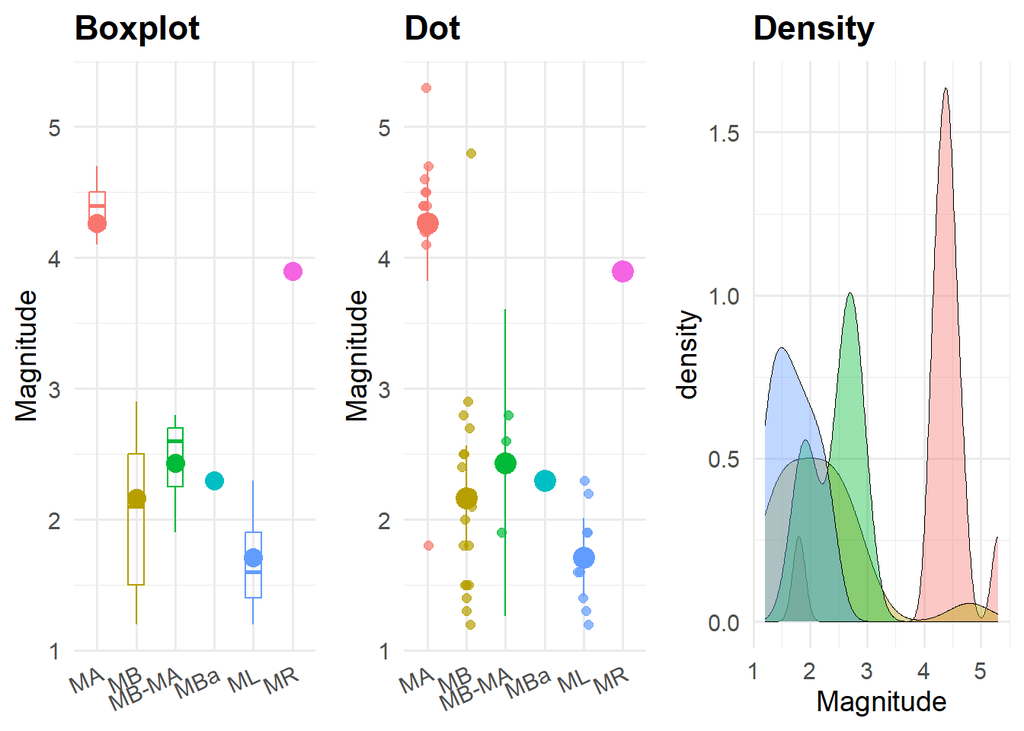

il n’y a pas une distribution normale de la donnée. Certains des types de magmas ne présentent qu’une seul variable.

```
## Levene's Test for Homogeneity of Variance (center = median)
##       Df F value Pr(>F)
## group  5  0.6567 0.6581
##       41
```

```
##             Df Sum Sq Mean Sq F value   Pr(>F)
## Mag.Type     5  50.18  10.036      19 9.66e-10 ***
## Residuals   41  21.65   0.528
## ---
## Signif. codes:  0 '***' 0.001 '**' 0.01 '*' 0.05 '.' 0.1 ' ' 1
```

```
##   Tukey multiple comparisons of means
##     95% family-wise confidence level
##
## Fit: aov(formula = Magnitude ~ Mag.Type, data = df)
##
## $Mag.Type
##                 diff        lwr        upr     p adj
## MB-MA     -2.1011278 -2.8661028 -1.3361528 0.0000000
## MB-MA-MA  -1.8309524 -3.2127069 -0.4491979 0.0037085
## MBa-MA    -1.9642857 -4.2123705  0.2837991 0.1174452
## ML-MA     -2.5531746 -3.4810929 -1.6252563 0.0000000
## MR-MA     -0.3642857 -2.6123705  1.8837991 0.9964721
## MB-MA-MB   0.2701754 -1.0791136  1.6194645 0.9905665
## MBa-MB     0.1368421 -2.0914354  2.3651196 0.9999688
## ML-MB     -0.4520468 -1.3308913  0.4267977 0.6429030
## MR-MB      1.7368421 -0.4914354  3.9651196 0.2058692
## MBa-MB-MA -0.1333333 -2.6411769  2.3745102 0.9999847
## ML-MB-MA  -0.7222222 -2.1701264  0.7256819 0.6718984
## MR-MB-MA   1.4666667 -1.0411769  3.9745102 0.5094360
## ML-MBa    -0.5888889 -2.8782264  1.7004486 0.9712470
## MR-MBa     1.6000000 -1.4714686  4.6714686 0.6305599
## MR-ML      2.1888889 -0.1004486  4.4782264 0.0680976
```

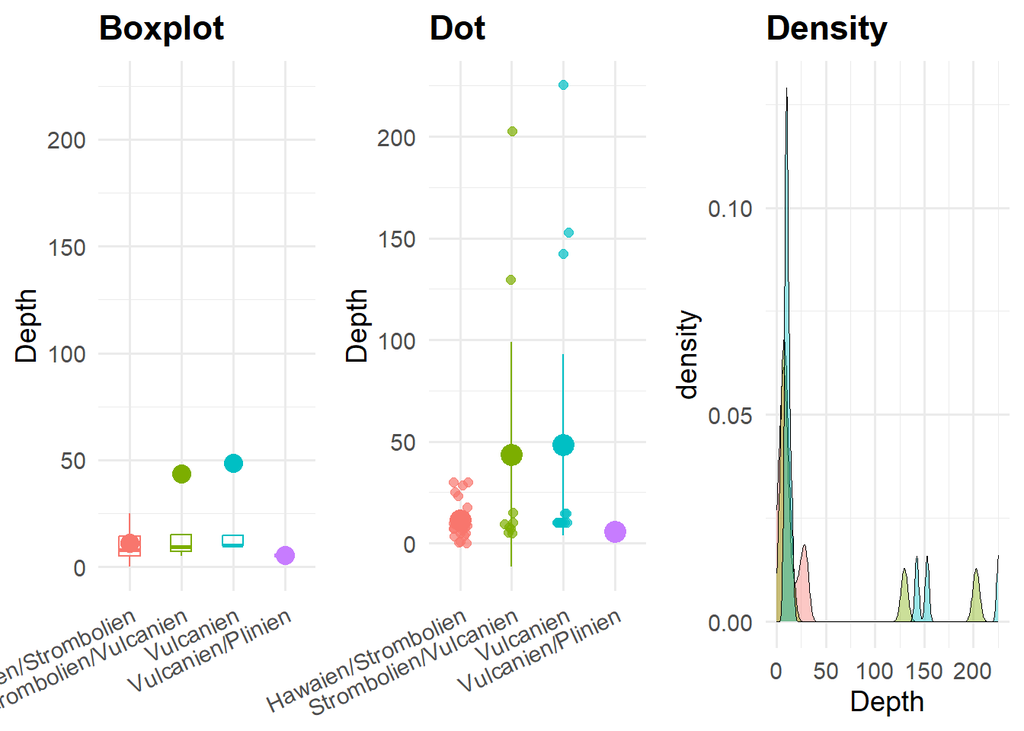

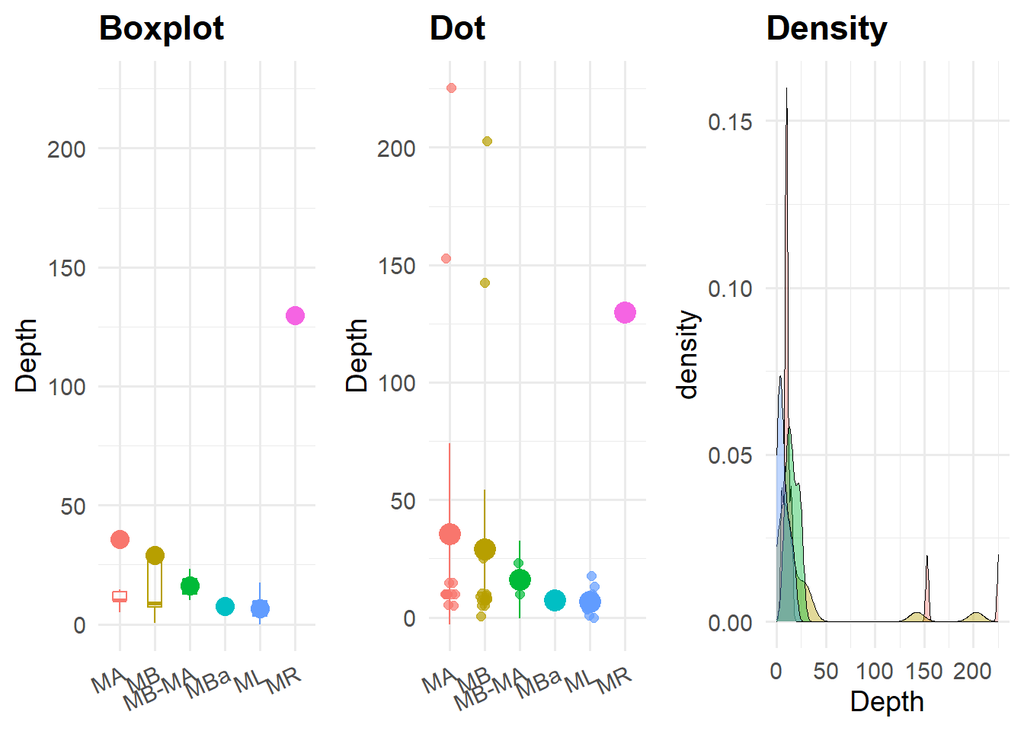

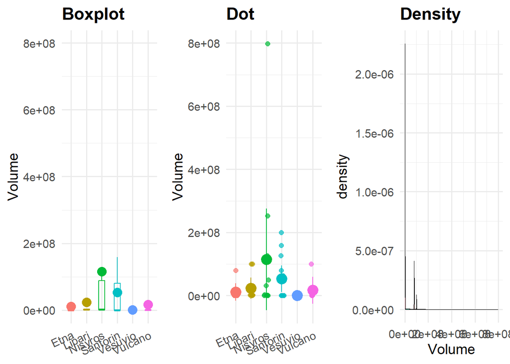

graphique : VEI + volcanoes

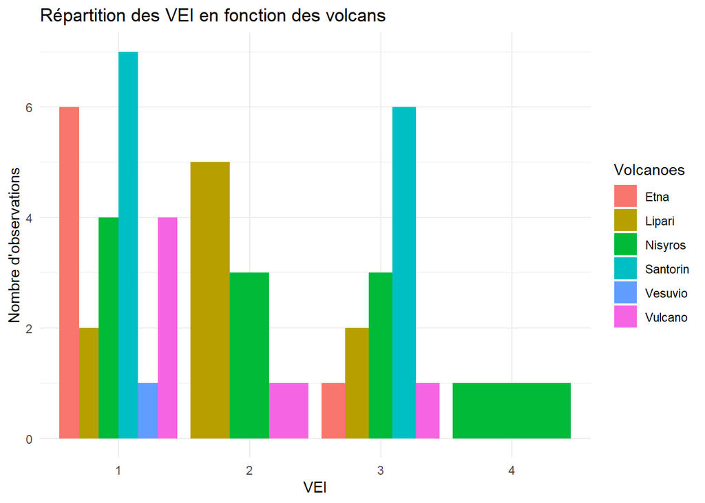

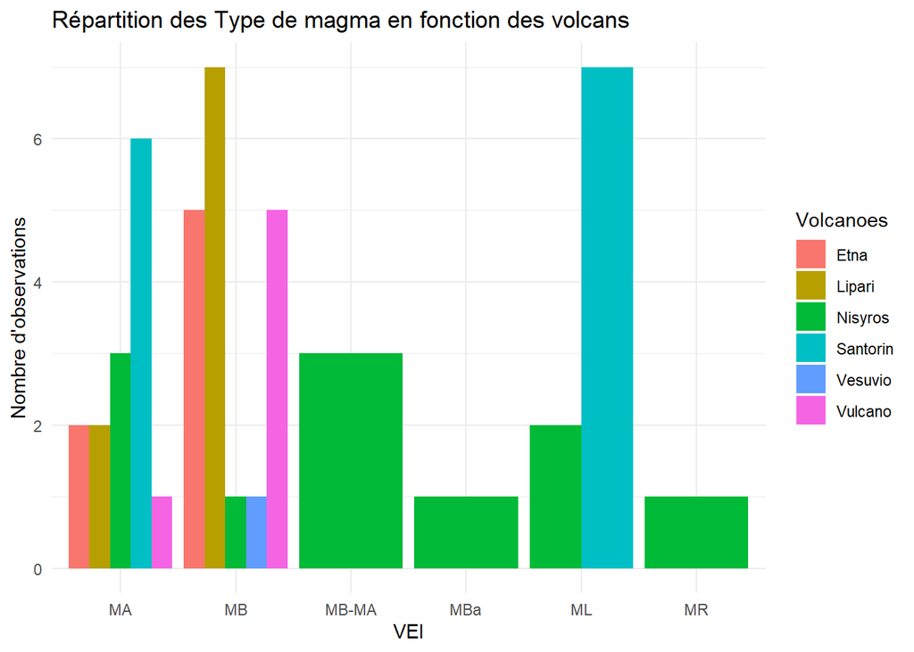

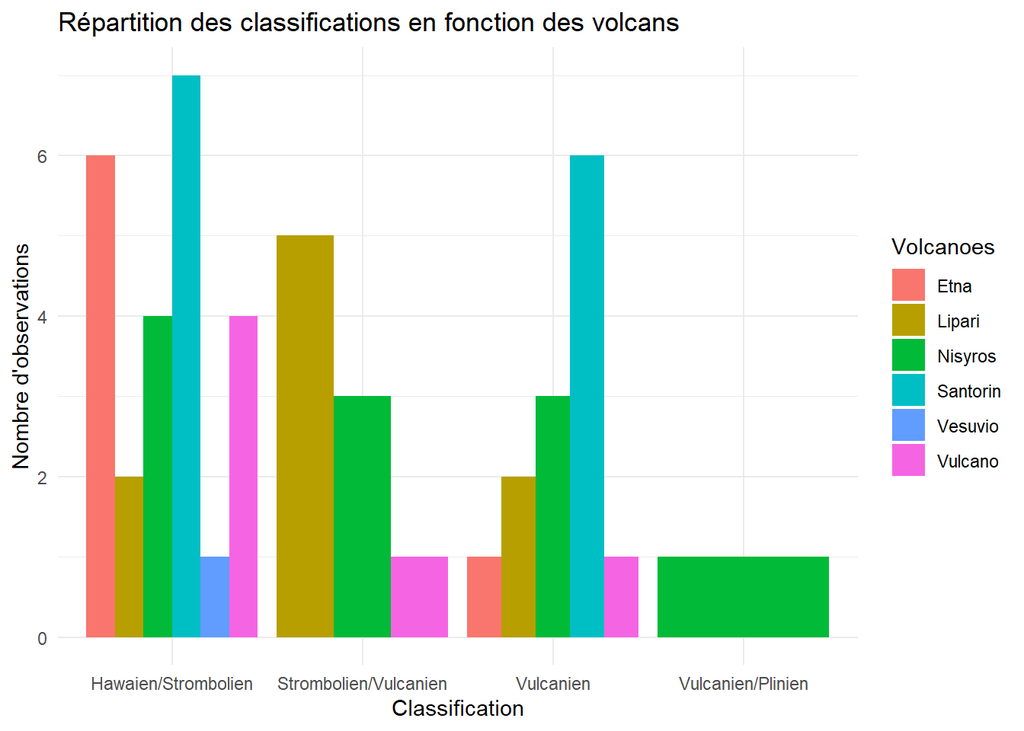

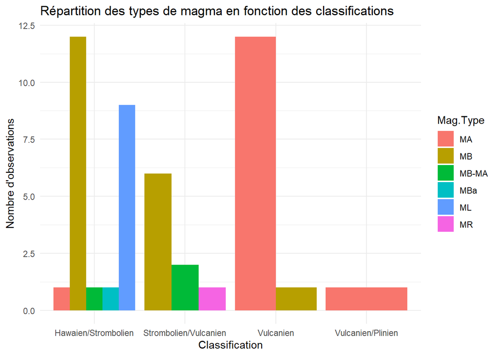

# 5 Analyse multivariée

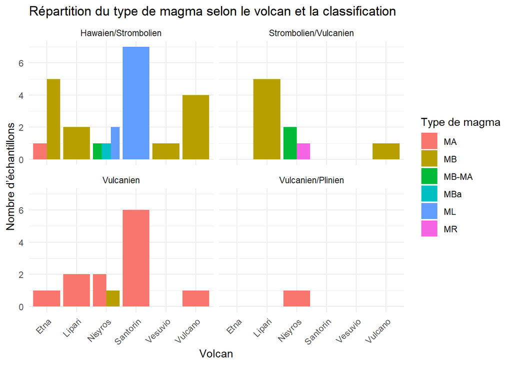